# Genetic_diversity_Ppinaster_study

Thomas Francisco

2025-10-27

```r
library(dplyr)
library(writexl)
library(ggplot2)
```

# 1 Introduction

This script estimates the genetic diversity at the individual level using the *Hi* calculation: number of heterozygous loci per individuals/total number of loci without missing data per individual) and also compute the inbreeding coefficient which is varying between 0: not inbreed to 1 completely inbreed. Calculations have been performed for different thresholds of minor allele frequency.

We are going to filter the raw genetic data file

```r
load("Data/Chapter3/Pinus_pinaster/genomic_data_newpop/Adults_offsprings_merge_df/data_Lacanau_tot.Rdata")
colnames(data_Lacanau_tot) <- gsub("\\.", "", colnames(data_Lacanau_tot))

load("Data/Chapter3/Pinus_pinaster/genomic_data_newpop/Adults_offsprings_merge_df/data_Tocchi_tot.Rdata")
colnames(data_Tocchi_tot) <- gsub("\\.", "", colnames(data_Tocchi_tot))
```

# 2 Genetic diversity and inbreeding with filtering out SNPs with mac < 3

```r
filter_mac_split <- function(df, mac_threshold = 3) {

  mac_values <- sapply(df, function(geno_col) {
    #Remove missing or empty
    geno_col <- geno_col[!is.na(geno_col) & geno_col != ""]

    #Split into alleles
    alleles <- unlist(strsplit(geno_col, split = ""))

    #Count alleles
    allele_counts <- table(alleles)

    #Compute minor allele count
    if (length(allele_counts) < 2) {
      mac <- 0
    } else {
      mac <- min(allele_counts)
    }

    return(mac)
  })

  #Logical vector for which SNPs to keep
  keep_snps <- mac_values >= mac_threshold

  #Filter dataframes
  df_keep <- df[, keep_snps, drop = FALSE]
  df_removed <- df[, !keep_snps, drop = FALSE]

  #Return both as a list
  return(list(
    kept = df_keep,
    removed = df_removed,
    mac_values = mac_values
  ))
}

result <- filter_mac_split(data_Lacanau_tot, mac_threshold = 3)
data_Lacanau_tot_filter_mac <- result$kept
df_removed_Lacanau  <- result$removed

result <- filter_mac_split(data_Tocchi_tot, mac_threshold = 3)
data_Tocchi_tot_filter_mac <- result$kept
df_removed_Tocchi  <- result$removed

#Remove singleton
result <- filter_mac_split(data_Lacanau_tot, mac_threshold = 1)
data_Lacanau_tot_filter_singleton <- result$kept
df_removed_Lacanau  <- result$removed

result <- filter_mac_split(data_Tocchi_tot, mac_threshold = 1)
data_Tocchi_tot_filter_singleton <- result$kept
df_removed_Tocchi  <- result$removed
```

## 2.1 Missing data per SNP

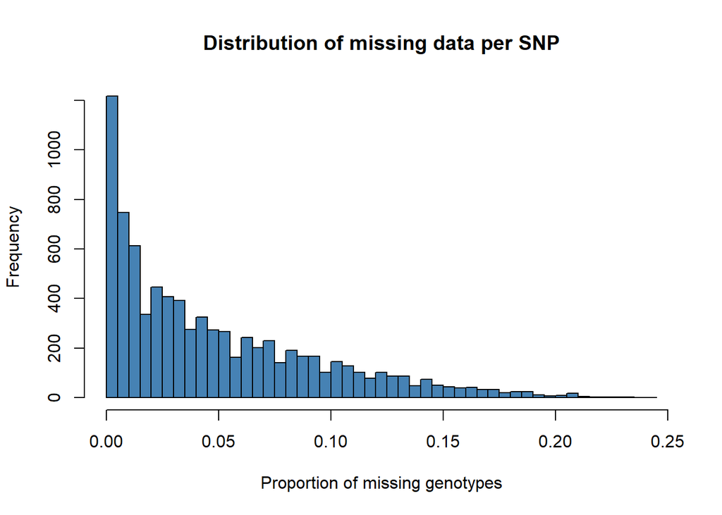

```r
#Lacanau
data_Lacanau_tot_filter_mac[data_Lacanau_tot_filter_mac == "---"] <- NA
missing_prop_Lacanau <- colMeans(is.na(data_Lacanau_tot_filter_mac) | data_Lacanau_tot_filter_mac == "")

hist(missing_prop_Lacanau,
     breaks = 50,
     col = "steelblue",
     main = "Distribution of missing data per SNP",
     xlab = "Proportion of missing genotypes")
```

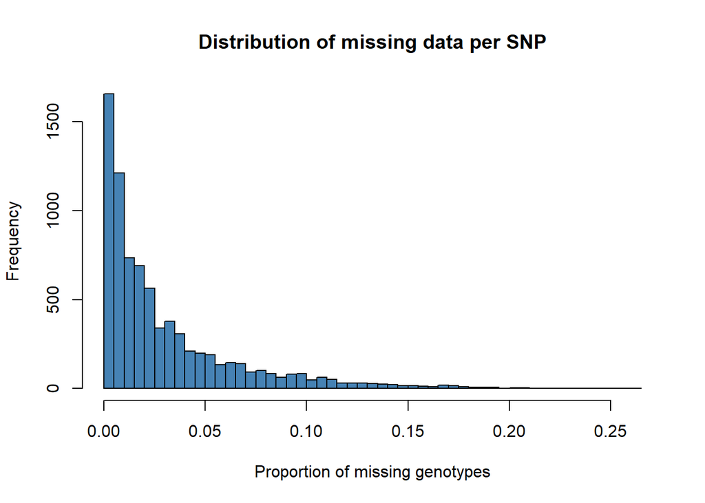

```r
missing_prop_Lacanau <- data.frame(colMeans(is.na(data_Lacanau_tot_filter_mac) | data_Lacanau_tot_filter_mac == ""))

#Tocchi
data_Tocchi_tot_filter_mac[data_Tocchi_tot_filter_mac == "---"] <- NA
missing_prop_Tocchi <- colMeans(is.na(data_Tocchi_tot_filter_mac) | data_Tocchi_tot_filter_mac == "")

hist(missing_prop_Tocchi,
     breaks = 50,
     col = "steelblue",
     main = "Distribution of missing data per SNP",
     xlab = "Proportion of missing genotypes")
```

```r
missing_prop_Tocchi <- data.frame(colMeans(is.na(data_Tocchi_tot_filter_mac) | data_Tocchi_tot_filter_mac == ""))
```

No need to remove any SNPs as the percentage of missing data is low

## 2.2 Missing data per individual

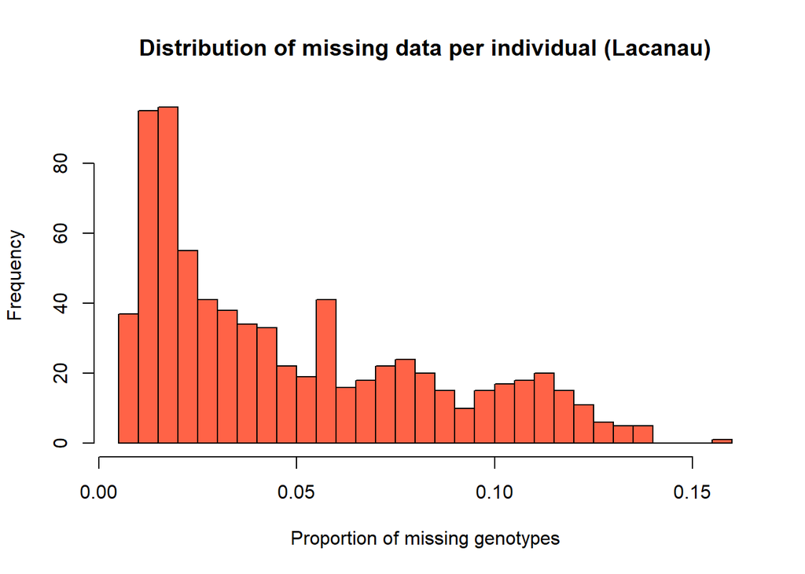

```r
#Lacanau
data_Lacanau_tot_filter_mac[data_Lacanau_tot_filter_mac == "---"] <- NA

#Missing data proportion per individual (rows)
missing_prop_Lacanau_ind <- rowMeans(is.na(data_Lacanau_tot_filter_mac) | data_Lacanau_tot_filter_mac == "")

#Plot distribution
hist(missing_prop_Lacanau_ind,
     breaks = 50,
     col = "tomato",
     main = "Distribution of missing data per individual (Lacanau)",
     xlab = "Proportion of missing genotypes")
```

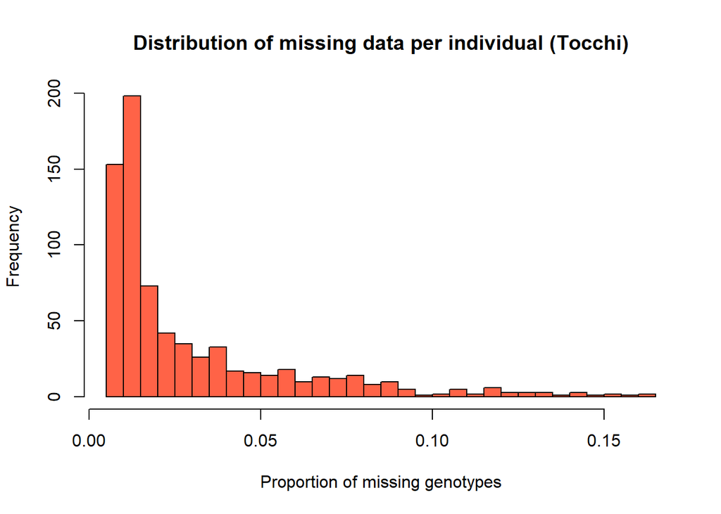

```r
missing_prop_Lacanau_ind <- data.frame(ID = rownames(data_Lacanau_tot_filter_mac),
                                       Missing_prop = missing_prop_Lacanau_ind)

#Tocchi
data_Tocchi_tot_filter_mac[data_Tocchi_tot_filter_mac == "---"] <- NA

missing_prop_Tocchi_ind <- rowMeans(is.na(data_Tocchi_tot_filter_mac) | data_Tocchi_tot_filter_mac == "")

hist(missing_prop_Tocchi_ind,
     breaks = 50,
     col = "tomato",
     main = "Distribution of missing data per individual (Tocchi)",
     xlab = "Proportion of missing genotypes")
```

```r
missing_prop_Tocchi_ind <- data.frame(ID = rownames(data_Tocchi_tot_filter_mac),
                                      Missing_prop = missing_prop_Tocchi_ind)
```

No need to remove any individuals as the percentage of missing data is low.

# 3 Computation of *Hi*

```r
#Function
compute_Hi <- function(x) {
  #Remove missing data
  x <- x[!is.na(x)]

  #Count heterozygous genotypes (two different alleles)
  hetero_count <- sum(nchar(x) == 2 & substring(x, 1, 1) != substring(x, 2, 2))

  #Count total non-missing loci
  total_non_missing <- length(x)

  #Avoid dividing by zero
  if (total_non_missing == 0) return(NA)

  return(hetero_count / total_non_missing)
}

#Compute Hi

##Lacanau
Hi_per_individual_Lacanau <- apply(data_Lacanau_tot_filter_mac, 1, compute_Hi)
Hi_df_Lacanau <- data.frame(
  ID = data_Lacanau_tot_filter_mac$POP,
  Hi = Hi_per_individual_Lacanau
)
save(Hi_df_Lacanau,file="Results/Chapter3/Pinaster/Genetic_diversity/Comparison_adults_juveniles/Hi/Values/Hi_df_Lacanau.Rdata")

Hi_per_individual_Lacanau_no_mac <- apply(data_Lacanau_tot, 1, compute_Hi)
Hi_df_Lacanau_no_mac <- data.frame(
  ID = data_Lacanau_tot$POP,
  Hi = Hi_per_individual_Lacanau_no_mac
)

save(Hi_df_Lacanau_no_mac,file="Results/Chapter3/Pinaster/Genetic_diversity/Comparison_adults_juveniles/Hi/Values/Hi_df_Lacanau_no_mac.Rdata")

##Tocchi
Hi_per_individual_Tocchi <- apply(data_Tocchi_tot_filter_mac, 1, compute_Hi)
Hi_df_Tocchi <- data.frame(
  ID = data_Tocchi_tot_filter_mac$POP,
  Hi = Hi_per_individual_Tocchi
)

save(Hi_df_Tocchi,file="Results/Chapter3/Pinaster/Genetic_diversity/Comparison_adults_juveniles/Hi/Values/Hi_df_Tocchi.Rdata")

Hi_per_individual_Tocchi_no_mac <- apply(data_Tocchi_tot, 1, compute_Hi)
Hi_df_Tocchi_no_mac <- data.frame(
  ID = data_Tocchi_tot$POP,
  Hi = Hi_per_individual_Tocchi_no_mac
)

save(Hi_df_Tocchi_no_mac,file="Results/Chapter3/Pinaster/Genetic_diversity/Comparison_adults_juveniles/Hi/Values/Hi_df_Tocchi_no_mac.Rdata")
```

## 3.1 Plot

We can compare Adults and juveniles values

```r
#Add info on juveniles and adults
Hi_df_Lacanau <- Hi_df_Lacanau %>%
  dplyr::mutate(age = ifelse(grepl("FR_PP", ID), "Offspring", "Adult"))

Hi_df_Tocchi <- Hi_df_Tocchi %>%
  dplyr::mutate(age = ifelse(grepl("IT_PP", ID), "Offspring", "Adult"))

Hi_df_Lacanau_no_mac <- Hi_df_Lacanau_no_mac %>%
  dplyr::mutate(age = ifelse(grepl("FR_PP", ID), "Offspring", "Adult"))

Hi_df_Tocchi_no_mac <- Hi_df_Tocchi_no_mac %>%
  dplyr::mutate(age = ifelse(grepl("IT_PP", ID), "Offspring", "Adult"))
```

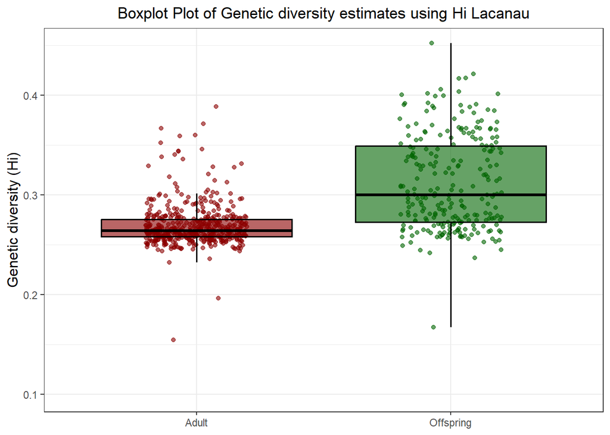

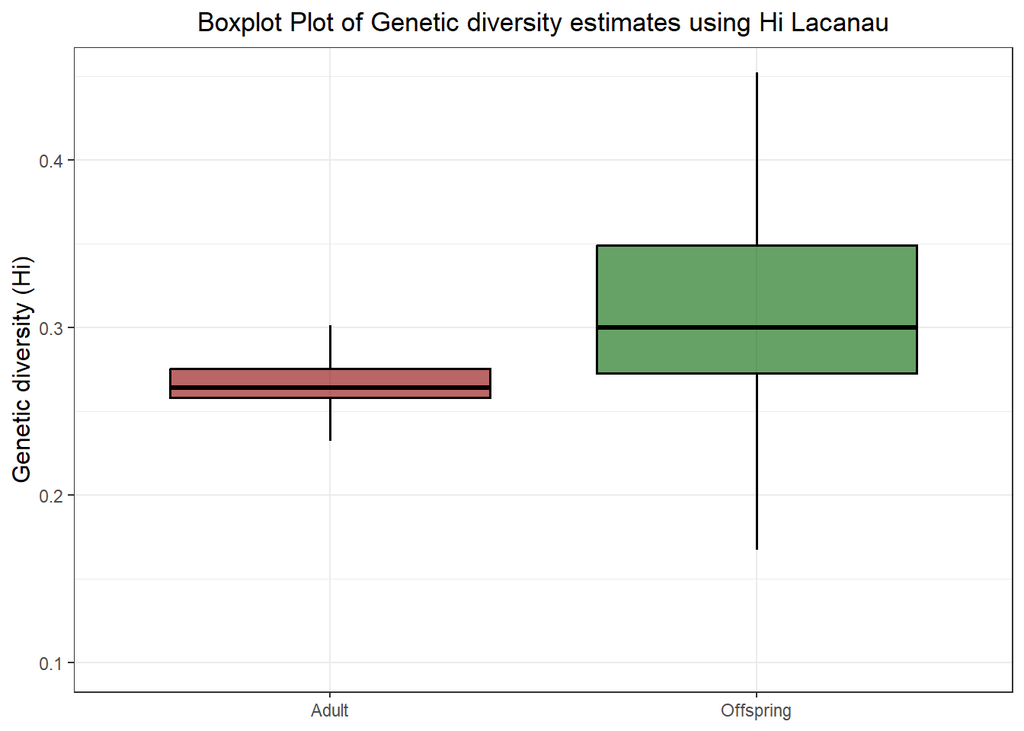

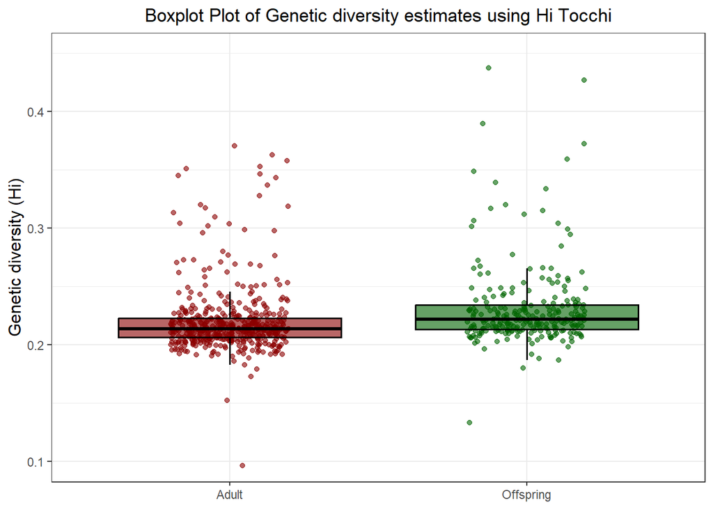

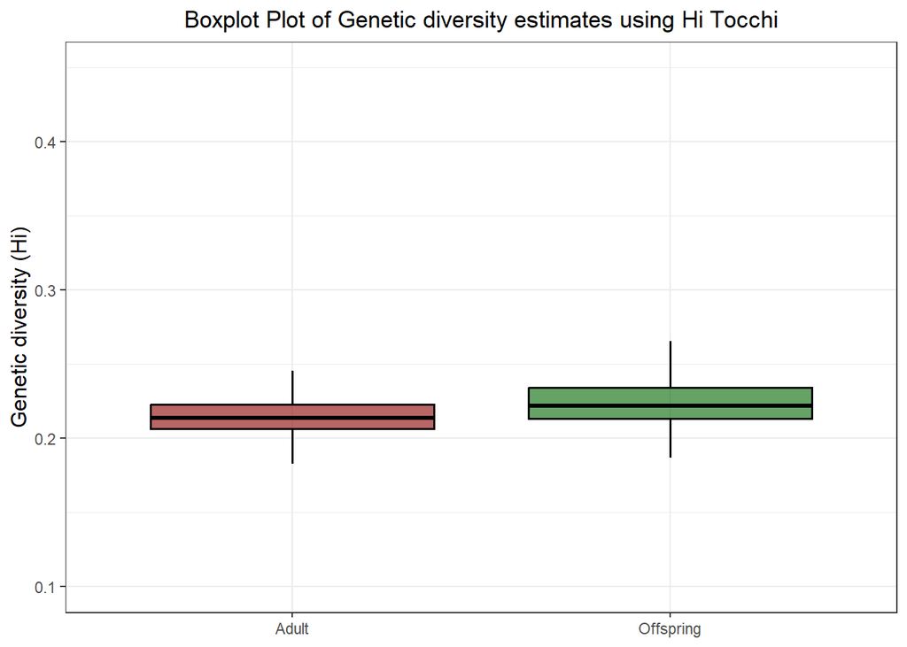

```r
list_plots <- c("Lacanau","Tocchi")

for(x in 1:length(list_plots)){

  plot <- list_plots[x]
  df_Hi<- get(paste0("Hi_df_",plot))

  t_test_result <- t.test(Hi ~ age, data = df_Hi)

    assign(paste0("Hi_difference_across_adults_juv_",plot),t_test_result)

  #Plot
Hi_boxplot <- ggplot(df_Hi, aes(x = age, y = Hi, fill = age)) +
  geom_jitter(aes(color = age), width = 0.2, alpha = 0.6, size = 1.5, show.legend = FALSE) +
  geom_boxplot(outlier.shape = NA, alpha = 0.6, color = "black", size = 0.6) +
  scale_fill_manual(values = c("darkred", "darkgreen")) +
  scale_color_manual(values = c("darkred", "darkgreen")) +
  labs(
    title = paste0("Boxplot Plot of Genetic diversity estimates using Hi ", plot),
    #x = "Group-age",
    y = "Genetic diversity (Hi)"
  ) +
  coord_cartesian(ylim = c(0.1, 0.45)) +
  scale_y_continuous(breaks = seq(0.1, 0.45, by = 0.1)) +
  theme_bw() +
  theme(
    plot.title = element_text(hjust = 0.5),
    legend.position = "none",
    axis.title.x = element_blank(),
    axis.title.y = element_text(size = 12)
  )

plot(Hi_boxplot)

pdf(paste0("Results/Chapter3/Pinaster/Genetic_diversity/Comparison_adults_juveniles/Hi/figures/Hi_boxplot_",plot,".pdf"), width = 8, height = 6)
print(Hi_boxplot)
dev.off()

Hi_boxplot_wo_points <- ggplot(df_Hi, aes(x = age, y = Hi, fill = age)) +
  #geom_jitter(aes(color = Group), width = 0.2, alpha = 0.6, size = 1.5, show.legend = FALSE) + #points
  geom_boxplot(outlier.shape = NA, alpha = 0.6, color = "black", size = 0.6) +
  scale_fill_manual(values = c("darkred", "darkgreen")) +
  scale_color_manual(values = c("darkred", "darkgreen")) +
  labs(
    title = paste0("Boxplot Plot of Genetic diversity estimates using Hi ", plot),
    #x = "Group-age",
    y = "Genetic diversity (Hi)"
  ) +
  coord_cartesian(ylim = c(0.1, 0.45)) +
  scale_y_continuous(breaks = seq(0.1, 0.45, by = 0.1)) +
  theme_bw() +
  theme(
    plot.title = element_text(hjust = 0.5),
    legend.position = "none",
    axis.title.x = element_blank(),
    axis.title.y = element_text(size = 12)
  )

plot(Hi_boxplot_wo_points)

pdf(paste0("Results/Chapter3/Pinaster/Genetic_diversity/Comparison_adults_juveniles/Hi/figures/Hi_boxplot_wopoints_",plot,".pdf"), width = 8, height = 6)
print(Hi_boxplot_wo_points)
dev.off()

}
```

```r
print(Hi_difference_across_adults_juv_Lacanau)
```

```
##
##  Welch Two Sample t-test
##
## data:  Hi by age
## t = -13.688, df = 297.7, p-value < 2.2e-16
## alternative hypothesis: true difference in means between group Adult and group Offspring is not equal to 0
## 95 percent confidence interval:
##  -0.04864043 -0.03641191
## sample estimates:
##     mean in group Adult mean in group Offspring
##               0.2691493               0.3116754
```

```r
print(Hi_difference_across_adults_juv_Tocchi)
```

```
##
##  Welch Two Sample t-test
##
## data:  Hi by age
## t = -4.2665, df = 414.03, p-value = 2.463e-05
## alternative hypothesis: true difference in means between group Adult and group Offspring is not equal to 0
## 95 percent confidence interval:
##  -0.016357947 -0.006038928
## sample estimates:
##     mean in group Adult mean in group Offspring
##               0.2202212               0.2314196
```

Hi without mac

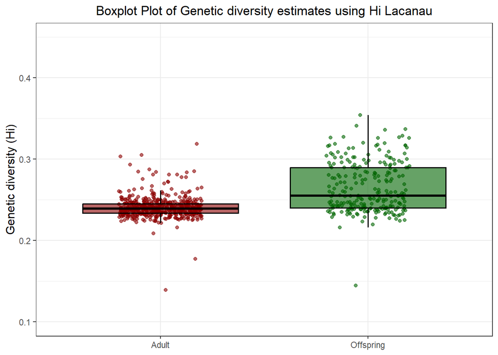

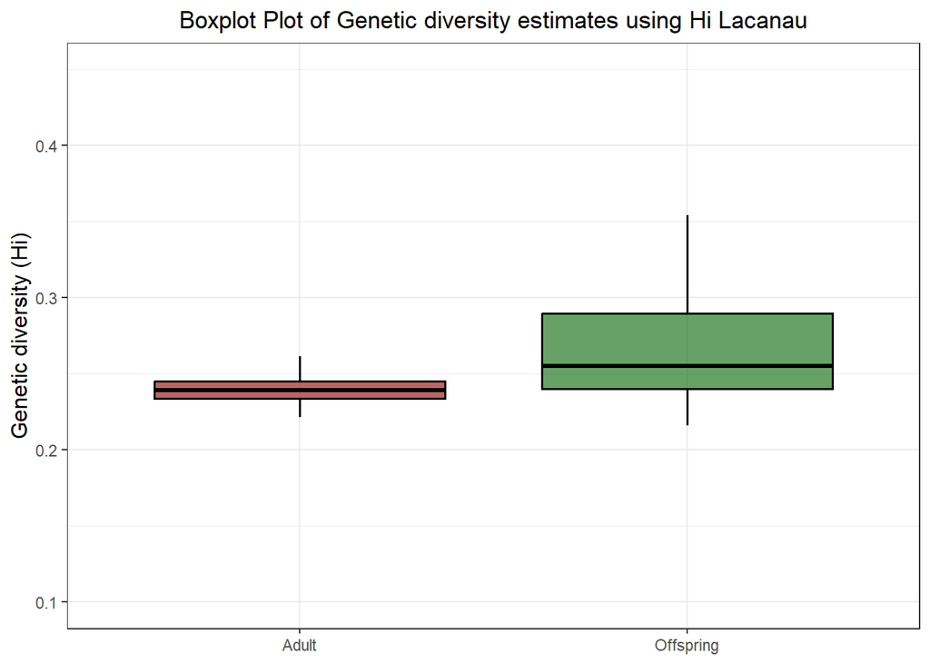

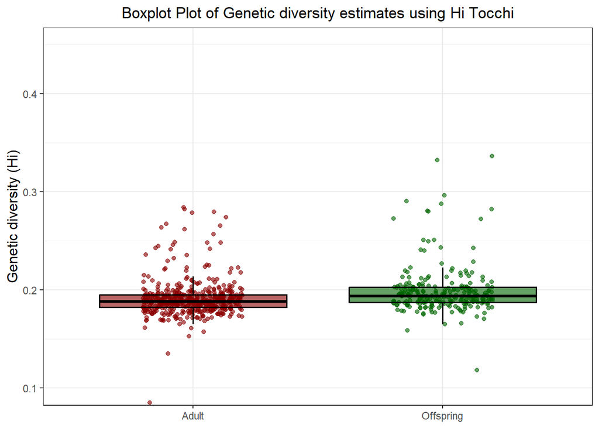

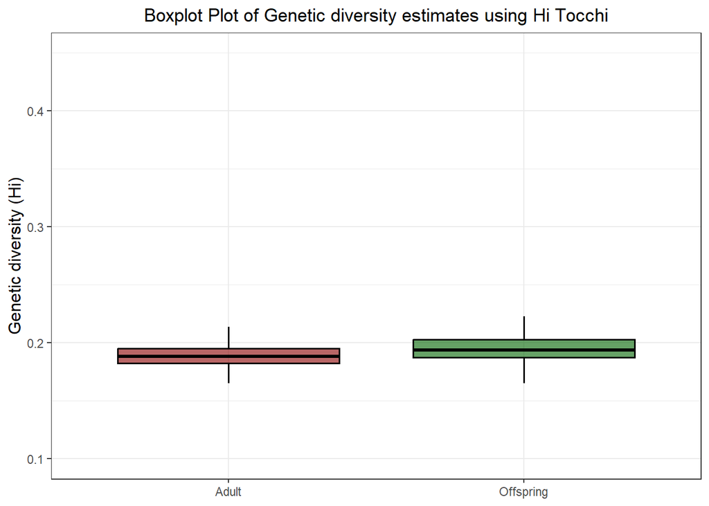

```r
list_plots <- c("Lacanau","Tocchi")

for(x in 1:length(list_plots)){

  plot <- list_plots[x]
  df_Hi<- get(paste0("Hi_df_",plot,"_no_mac"))

  t_test_result <- t.test(Hi ~ age, data = df_Hi)

    assign(paste0("Hi_difference_across_adults_juv_",plot),t_test_result)


  #Plot
Hi_boxplot <- ggplot(df_Hi, aes(x = age, y = Hi, fill = age)) +
  geom_jitter(aes(color = age), width = 0.2, alpha = 0.6, size = 1.5, show.legend = FALSE) +
  geom_boxplot(outlier.shape = NA, alpha = 0.6, color = "black", size = 0.6) +
  scale_fill_manual(values = c("darkred", "darkgreen")) +
  scale_color_manual(values = c("darkred", "darkgreen")) +
  labs(
    title = paste0("Boxplot Plot of Genetic diversity estimates using Hi ", plot),
    #x = "Group-age",
    y = "Genetic diversity (Hi)"
  ) +
  coord_cartesian(ylim = c(0.1, 0.45)) +
  scale_y_continuous(breaks = seq(0.1, 0.45, by = 0.1)) +
  theme_bw() +
  theme(
    plot.title = element_text(hjust = 0.5),
    legend.position = "none",
    axis.title.x = element_blank(),
    axis.title.y = element_text(size = 12)
  )

plot(Hi_boxplot)

pdf(paste0("Results/Chapter3/Pinaster/Genetic_diversity/Comparison_adults_juveniles/Hi/figures/Hi_boxplot_",plot,"_no_mac.pdf"), width = 8, height = 6)
print(Hi_boxplot)
dev.off()

Hi_boxplot_wo_points <- ggplot(df_Hi, aes(x = age, y = Hi, fill = age)) +
  #geom_jitter(aes(color = Group), width = 0.2, alpha = 0.6, size = 1.5, show.legend = FALSE) + #points
  geom_boxplot(outlier.shape = NA, alpha = 0.6, color = "black", size = 0.6) +
  scale_fill_manual(values = c("darkred", "darkgreen")) +
  scale_color_manual(values = c("darkred", "darkgreen")) +
  labs(
    title = paste0("Boxplot Plot of Genetic diversity estimates using Hi ", plot),
    #x = "Group-age",
    y = "Genetic diversity (Hi)"
  ) +
  coord_cartesian(ylim = c(0.1, 0.45)) +
  scale_y_continuous(breaks = seq(0.1, 0.45, by = 0.1)) +
  theme_bw() +
  theme(
    plot.title = element_text(hjust = 0.5),
    legend.position = "none",
    axis.title.x = element_blank(),
    axis.title.y = element_text(size = 12)
  )

plot(Hi_boxplot_wo_points)

pdf(paste0("Results/Chapter3/Pinaster/Genetic_diversity/Comparison_adults_juveniles/Hi/figures/Hi_boxplot_wopoints_",plot,"_no_mac.pdf"), width = 8, height = 6)
print(Hi_boxplot_wo_points)
dev.off()

}
```

```r
print(Hi_difference_across_adults_juv_Lacanau)
```

```
##
##  Welch Two Sample t-test
##
## data:  Hi by age
## t = -11.913, df = 294.82, p-value < 2.2e-16
## alternative hypothesis: true difference in means between group Adult and group Offspring is not equal to 0
## 95 percent confidence interval:
##  -0.02824187 -0.02023358
## sample estimates:
##     mean in group Adult mean in group Offspring
##               0.2409110               0.2651487
```

```r
print(Hi_difference_across_adults_juv_Tocchi)
```

```
##
##  Welch Two Sample t-test
##
## data:  Hi by age
## t = -4.3549, df = 394.65, p-value = 1.699e-05
## alternative hypothesis: true difference in means between group Adult and group Offspring is not equal to 0
## 95 percent confidence interval:
##  -0.011245752 -0.004250253
## sample estimates:
##     mean in group Adult mean in group Offspring
##               0.1913048               0.1990528
```

Plots with the two populations:

Full legend

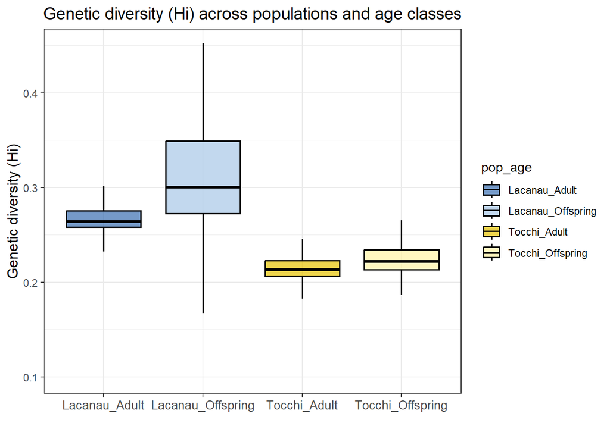

```r
#Merge the two datasets and create a new combined category
df_all <- rbind(
  transform(Hi_df_Lacanau, population = "Lacanau"),
  transform(Hi_df_Tocchi, population = "Tocchi")
)

#Create combined factor for x-axis: Population + Age
df_all$pop_age <- factor(
  paste(df_all$population, df_all$age, sep = "_"),
  levels = c("Lacanau_Adult","Lacanau_Offspring",
             "Tocchi_Adult","Tocchi_Offspring")
)

#Colors:
custom_colors <- c(
  "Lacanau_Adult"     = "#3A6FB0",
   "Lacanau_Offspring" = "#A7C7E7",
  "Tocchi_Adult"      = "#E6C300",
    "Tocchi_Offspring"  = "#FFF4A3"
)

legend_colors <- c(
  "Lacanau" = "#3A6FB0",
  "Tocchi"  = "#E6C300"
)

combined_boxplot <- ggplot(df_all, aes(x = pop_age, y = Hi, fill = pop_age)) +
  geom_boxplot(outlier.shape = NA, alpha = 0.7, color = "black", size = 0.6) +
  labs(
    title = "Genetic diversity (Hi) across populations and age classes",
    x = "",
    y = "Genetic diversity (Hi)"
  ) +
   scale_fill_manual(values = custom_colors) +
  coord_cartesian(ylim = c(0.1, 0.45)) +
  theme_bw() +
  theme(
    plot.title = element_text(hjust = 0.5, size = 14),
    axis.title = element_text(size = 12),
    axis.text.x = element_text(size = 10)
  )

plot(combined_boxplot)
```

Without mac

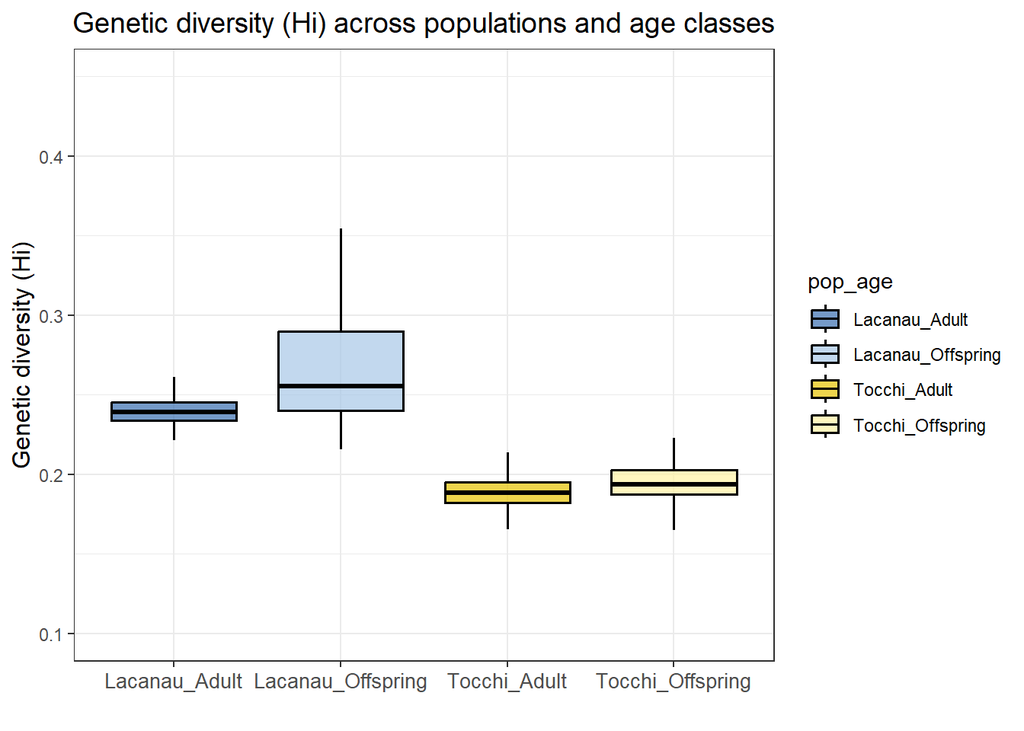

```r
#Merge the two datasets and create a new combined category
df_all_no_mac <- rbind(
  transform(Hi_df_Lacanau_no_mac, population = "Lacanau"),
  transform(Hi_df_Tocchi_no_mac, population = "Tocchi")
)

#Create combined factor for x-axis: Population + Age
df_all_no_mac$pop_age <- factor(
  paste(df_all_no_mac$population, df_all_no_mac$age, sep = "_"),
  levels = c("Lacanau_Adult","Lacanau_Offspring",
             "Tocchi_Adult","Tocchi_Offspring")
)

#Colors:
custom_colors <- c(
  "Lacanau_Adult"     = "#3A6FB0",
   "Lacanau_Offspring" = "#A7C7E7",
  "Tocchi_Adult"      = "#E6C300",
    "Tocchi_Offspring"  = "#FFF4A3"
)

legend_colors <- c(
  "Lacanau" = "#3A6FB0",
  "Tocchi"  = "#E6C300"
)

combined_boxplot <- ggplot(df_all_no_mac, aes(x = pop_age, y = Hi, fill = pop_age)) +
  geom_boxplot(outlier.shape = NA, alpha = 0.7, color = "black", size = 0.6) +
  labs(
    title = "Genetic diversity (Hi) across populations and age classes",
    x = "",
    y = "Genetic diversity (Hi)"
  ) +
   scale_fill_manual(values = custom_colors) +
  coord_cartesian(ylim = c(0.1, 0.45)) +
  theme_bw() +
  theme(
    plot.title = element_text(hjust = 0.5, size = 14),
    axis.title = element_text(size = 12),
    axis.text.x = element_text(size = 10)
  )

plot(combined_boxplot)
```

Test significance:

```r
#One way anova to see if groups are differents
anova_result <- aov(Hi ~ pop_age, data = df_all)
summary(anova_result)
```

```
##               Df Sum Sq Mean Sq F value Pr(>F)
## pop_age        3  1.622  0.5406   541.2 <2e-16 ***
## Residuals   1477  1.475  0.0010
## ---
## Signif. codes:  0 '***' 0.001 '**' 0.01 '*' 0.05 '.' 0.1 ' ' 1
```

```r
tukey_result <- TukeyHSD(anova_result)
tukey_result
```

```
##   Tukey multiple comparisons of means
##     95% family-wise confidence level
##
## Fit: aov(formula = Hi ~ pop_age, data = df_all)
##
## $pop_age
##                                           diff          lwr         upr
## Lacanau_Offspring-Lacanau_Adult     0.04252617  0.036221304  0.04883104
## Tocchi_Adult-Lacanau_Adult         -0.04892809 -0.054111435 -0.04374475
## Tocchi_Offspring-Lacanau_Adult     -0.03772966 -0.044043007 -0.03141631
## Tocchi_Adult-Lacanau_Offspring     -0.09145427 -0.097793688 -0.08511485
## Tocchi_Offspring-Lacanau_Offspring -0.08025583 -0.087548265 -0.07296340
## Tocchi_Offspring-Tocchi_Adult       0.01119844  0.004850584  0.01754629
##                                       p adj
## Lacanau_Offspring-Lacanau_Adult    0.00e+00
## Tocchi_Adult-Lacanau_Adult         0.00e+00
## Tocchi_Offspring-Lacanau_Adult     0.00e+00
## Tocchi_Adult-Lacanau_Offspring     0.00e+00
## Tocchi_Offspring-Lacanau_Offspring 0.00e+00
## Tocchi_Offspring-Tocchi_Adult      3.65e-05
```

```r
#Compared Lacanau (adults+juveniles) and Tocchi (adults+juveniles)
anova_result_pop <- aov(Hi ~ population, data = df_all)
summary(anova_result_pop)
```

```
##               Df Sum Sq Mean Sq F value Pr(>F)
## population     1  1.301  1.3006    1071 <2e-16 ***
## Residuals   1479  1.796  0.0012
## ---
## Signif. codes:  0 '***' 0.001 '**' 0.01 '*' 0.05 '.' 0.1 ' ' 1
```

```r
df_Lac_bsi_adults <- df_all %>% filter(pop_age=="Lacanau_Adult")
mean(df_Lac_bsi_adults$Hi)
```

```
## [1] 0.2691493
```

```r
df_Lac_bsi_juv <- df_all %>% filter(pop_age=="Lacanau_Offspring")
mean(df_Lac_bsi_juv$Hi)
```

```
## [1] 0.3116754
```

```r
df_Lac_bsi <- df_all %>% filter(population=="Lacanau")
mean(df_Lac_bsi$Hi)
```

```
## [1] 0.2832868
```

```r
df_Toc_bsi <- df_all %>% filter(population=="Tocchi")
mean(df_Toc_bsi$Hi)
```

```
## [1] 0.2240152
```

```r
df_Toc_bsi_adults <- df_all %>% filter(pop_age=="Tocchi_Adult")
mean(df_Toc_bsi_adults$Hi)
```

```
## [1] 0.2202212
```

```r
df_Toc_bsi_juv <- df_all %>% filter(pop_age=="Tocchi_Offspring")
mean(df_Toc_bsi_juv$Hi)
```

```
## [1] 0.2314196
```

Without the mac threshold

```r
#One way anova to see if groups are differents
anova_result <- aov(Hi ~ pop_age, data = df_all_no_mac)
summary(anova_result)
```

```
##               Df Sum Sq Mean Sq F value Pr(>F)
## pop_age        3 1.2289  0.4096   947.5 <2e-16 ***
## Residuals   1477 0.6385  0.0004
## ---
## Signif. codes:  0 '***' 0.001 '**' 0.01 '*' 0.05 '.' 0.1 ' ' 1
```

```r
tukey_result <- TukeyHSD(anova_result)
tukey_result
```

```
##   Tukey multiple comparisons of means
##     95% family-wise confidence level
##
## Fit: aov(formula = Hi ~ pop_age, data = df_all_no_mac)
##
## $pop_age
##                                            diff          lwr         upr
## Lacanau_Offspring-Lacanau_Adult     0.024237723  0.020089845  0.02838560
## Tocchi_Adult-Lacanau_Adult         -0.049606162 -0.053016203 -0.04619612
## Tocchi_Offspring-Lacanau_Adult     -0.041858160 -0.046011616 -0.03770470
## Tocchi_Adult-Lacanau_Offspring     -0.073843885 -0.078014493 -0.06967328
## Tocchi_Offspring-Lacanau_Offspring -0.066095883 -0.070893465 -0.06129830
## Tocchi_Offspring-Tocchi_Adult       0.007748002  0.003571846  0.01192416
##                                       p adj
## Lacanau_Offspring-Lacanau_Adult    0.00e+00
## Tocchi_Adult-Lacanau_Adult         0.00e+00
## Tocchi_Offspring-Lacanau_Adult     0.00e+00
## Tocchi_Adult-Lacanau_Offspring     0.00e+00
## Tocchi_Offspring-Lacanau_Offspring 0.00e+00
## Tocchi_Offspring-Tocchi_Adult      1.19e-05
```

```r
#Compared Lacanau (adults+juveniles) and Tocchi (adults+juveniles)
anova_result_pop <- aov(Hi ~ population, data = df_all_no_mac)
summary(anova_result_pop)
```

```
##               Df Sum Sq Mean Sq F value Pr(>F)
## population     1  1.121  1.1214    2223 <2e-16 ***
## Residuals   1479  0.746  0.0005
## ---
## Signif. codes:  0 '***' 0.001 '**' 0.01 '*' 0.05 '.' 0.1 ' ' 1
```

```r
df_Lac_bsi_adults <- df_all_no_mac %>% filter(pop_age=="Lacanau_Adult")
mean(df_Lac_bsi_adults$Hi)
```

```
## [1] 0.240911
```

```r
df_Lac_bsi_juv <- df_all_no_mac %>% filter(pop_age=="Lacanau_Offspring")
mean(df_Lac_bsi_juv$Hi)
```

```
## [1] 0.2651487
```

```r
df_Lac_bsi <- df_all_no_mac %>% filter(population=="Lacanau")
mean(df_Lac_bsi$Hi)
```

```
## [1] 0.2489686
```

```r
df_Toc_bsi <- df_all_no_mac %>% filter(population=="Tocchi")
mean(df_Toc_bsi$Hi)
```

```
## [1] 0.1939298
```

```r
df_Toc_bsi_adults <- df_all_no_mac %>% filter(pop_age=="Tocchi_Adult")
mean(df_Toc_bsi_adults$Hi)
```

```
## [1] 0.1913048
```

```r
df_Toc_bsi_juv <- df_all_no_mac %>% filter(pop_age=="Tocchi_Offspring")
mean(df_Toc_bsi_juv$Hi)
```

```
## [1] 0.1990528
```

Reduced legend but not colored

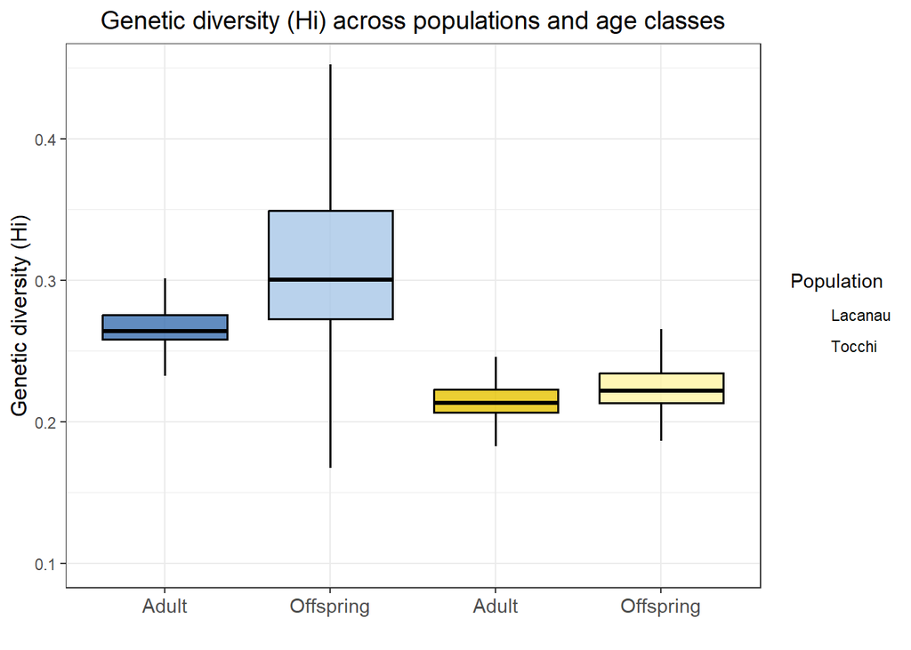

```r
#Merge the two datasets
df_all <- rbind(
  transform(Hi_df_Lacanau, population = "Lacanau"),
  transform(Hi_df_Tocchi, population = "Tocchi")
)

#Combined x-axis variable
df_all$pop_age <- factor(
  paste(df_all$population, df_all$age, sep = "_"),
  levels = c("Lacanau_Adult","Lacanau_Offspring",
             "Tocchi_Adult","Tocchi_Offspring")
)

#4 colors = shades used for the boxes
shade_colors <- c(
  "Lacanau_Adult"     = "#3A6FB0",
  "Lacanau_Offspring" = "#A7C7E7",
  "Tocchi_Adult"      = "#E6C300",
  "Tocchi_Offspring"  = "#FFF4A3"
)

#Legend = 1 color per population
legend_colors <- c(
  "Lacanau" = "#3A6FB0",
  "Tocchi"  = "#E6C300"
)

combined_boxplot <- ggplot(df_all, aes(x = pop_age, y = Hi)) +

  geom_boxplot(aes(fill = pop_age),
               outlier.shape = NA, alpha = 0.8, color = "black", size = 0.6) +
  geom_boxplot(aes(fill = population),
               alpha = 0, color = NA, show.legend = TRUE) +

  #SHADING colors (4 combinations)
  scale_fill_manual(
    values = c(shade_colors, legend_colors),
    breaks = names(legend_colors),      # only Lacanau, Tocchi appear
    labels = names(legend_colors),      # simple clean labels
    guide = guide_legend(title = "Population")
  ) +

  #Fix x-axis labels
  scale_x_discrete(
    labels = c("Adult", "Offspring", "Adult", "Offspring")
  ) +

  labs(
    title = "Genetic diversity (Hi) across populations and age classes",
    x = "",
    y = "Genetic diversity (Hi)"
  ) +
  coord_cartesian(ylim = c(0.1, 0.45)) +
  theme_bw() +
  theme(
    plot.title = element_text(hjust = 0.5, size = 14),
    axis.title.y = element_text(size = 12),
    axis.text.x = element_text(size = 11)
  )

plot(combined_boxplot)
```

```r
pdf("Results/Chapter3/Pinaster/Genetic_diversity/Comparison_adults_juveniles/Hi/figures/Hi_combined_boxplot_pop_colored_boxplots.pdf",
    width = 10, height = 6)
print(combined_boxplot)
dev.off()
```

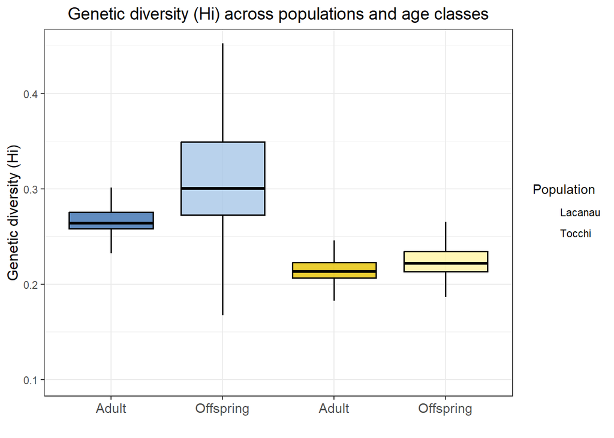

```r
#Merge the two datasets
df_all_no_mac <- rbind(
  transform(Hi_df_Lacanau, population = "Lacanau"),
  transform(Hi_df_Tocchi, population = "Tocchi")
)

#Combined x-axis variable
df_all_no_mac$pop_age <- factor(
  paste(df_all_no_mac$population, df_all_no_mac$age, sep = "_"),
  levels = c("Lacanau_Adult","Lacanau_Offspring",
             "Tocchi_Adult","Tocchi_Offspring")
)

#4 colors = shades used for the boxes
shade_colors <- c(
  "Lacanau_Adult"     = "#3A6FB0",
  "Lacanau_Offspring" = "#A7C7E7",
  "Tocchi_Adult"      = "#E6C300",
  "Tocchi_Offspring"  = "#FFF4A3"
)

#Legend = 1 color per population
legend_colors <- c(
  "Lacanau" = "#3A6FB0",
  "Tocchi"  = "#E6C300"
)

combined_boxplot <- ggplot(df_all_no_mac, aes(x = pop_age, y = Hi)) +

  geom_boxplot(aes(fill = pop_age),
               outlier.shape = NA, alpha = 0.8, color = "black", size = 0.6) +
  geom_boxplot(aes(fill = population),
               alpha = 0, color = NA, show.legend = TRUE) +

  #SHADING colors (4 combinations)
  scale_fill_manual(
    values = c(shade_colors, legend_colors),
    breaks = names(legend_colors),      #only Lacanau, Tocchi appear
    labels = names(legend_colors),
    guide = guide_legend(title = "Population")
  ) +

  #Fix x-axis labels
  scale_x_discrete(
    labels = c("Adult", "Offspring", "Adult", "Offspring")
  ) +

  labs(
    title = "Genetic diversity (Hi) across populations and age classes",
    x = "",
    y = "Genetic diversity (Hi)"
  ) +
  coord_cartesian(ylim = c(0.1, 0.45)) +
  theme_bw() +
  theme(
    plot.title = element_text(hjust = 0.5, size = 14),
    axis.title.y = element_text(size = 12),
    axis.text.x = element_text(size = 11)
  )

plot(combined_boxplot)
```

```r
pdf("Results/Chapter3/Pinaster/Genetic_diversity/Comparison_adults_juveniles/Hi/figures/Hi_combined_boxplot_pop_colored_boxplots_no_mac.pdf",
    width = 10, height = 6)
print(combined_boxplot)
dev.off()
```

Legend colored but not the points

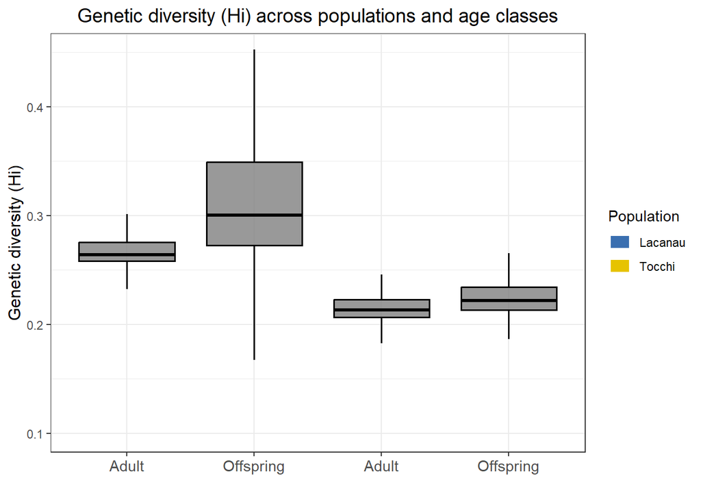

```r
#Merge
df_all <- rbind(
  transform(Hi_df_Lacanau, population = "Lacanau"),
  transform(Hi_df_Tocchi, population = "Tocchi")
)

#Pop-age x-axis variable
df_all$pop_age <- factor(
  paste(df_all$population, df_all$age, sep = "_"),
  levels = c("Lacanau_Adult","Lacanau_Offspring",
             "Tocchi_Adult","Tocchi_Offspring")
)

#4 shades (box colors)
shade_colors <- c(
  "Lacanau_Adult"     = "#3A6FB0",
  "Lacanau_Offspring" = "#A7C7E7",
  "Tocchi_Adult"      = "#E6C300",
  "Tocchi_Offspring"  = "#FFF4A3"
)

#Add a column with the actual hex color for each row
df_all$shade <- shade_colors[df_all$pop_age]

#Legend colors
legend_colors <- c(
  "Lacanau" = "#3A6FB0",
  "Tocchi"  = "#E6C300"
)

combined_boxplot <- ggplot(df_all, aes(x = pop_age, y = Hi)) +

  #main boxes use the 4 shades
  geom_boxplot(aes(fill = shade),
               color = "black", outlier.shape = NA, size = 0.6, alpha = 0.8) +

  geom_boxplot(aes(fill = population),
               alpha = 0, color = NA, show.legend = TRUE) +

  scale_fill_identity(guide = "none") +

  scale_fill_manual(
    name = "Population",
    values = legend_colors,
    breaks = names(legend_colors),
    guide = guide_legend(override.aes = list(alpha = 1))
  ) +

  scale_x_discrete(labels = c("Adult", "Offspring", "Adult", "Offspring")) +

  labs(
    title = "Genetic diversity (Hi) across populations and age classes",
    x = "",
    y = "Genetic diversity (Hi)"
  ) +
  coord_cartesian(ylim = c(0.1, 0.45)) +

  theme_bw() +
  theme(
    plot.title = element_text(hjust = 0.5, size = 14),
    axis.title.y = element_text(size = 12),
    axis.text.x = element_text(size = 11)
  )

plot(combined_boxplot)
```

```r
pdf("Results/Chapter3/Pinaster/Genetic_diversity/Comparison_adults_juveniles/Hi/figures/Hi_combined_boxplot_pop_colored_legend.pdf",
    width = 10, height = 6)
print(combined_boxplot)
dev.off()
```

# 4 Compute inbreeding coefficient F

We combined adult and juvenile cohorts for each population.

Compute the F inbreeding coeff Lacanau:

```r
#geno_nuc: matrix of nucleotide genotypes, rows=individuals, cols=SNPs
geno_nuc_Lacanau <- as.matrix(data_Lacanau_tot_filter_mac[,-1])

compute_Ho <- function(x) {
  x <- x[!is.na(x)]
  #Heterozygous if two alleles are different
  hetero <- sum(substr(x,1,1) != substr(x,2,2))
  return(hetero / length(x))
}

Ho_Lacanau <- data.frame(ID=data_Lacanau_tot_filter_mac$POP,apply(geno_nuc_Lacanau, 1, compute_Ho))


compute_He <- function(geno_matrix) {
  n_snp <- ncol(geno_matrix)
  He <- numeric(n_snp)

  for (i in 1:n_snp) {
    col <- geno_matrix[,i]
    col <- col[!is.na(col)]

    #Split each genotype into alleles
    alleles <- unlist(strsplit(col, ""))

    #Count allele frequencies
    freq_table <- table(alleles) / sum(table(alleles))

    #If less than 2 alleles, He = 0
    if (length(freq_table) < 2) {
      He[i] <- 0
    } else {
      # Take two most frequent alleles
      p1 <- sort(freq_table, decreasing = TRUE)[1]
      p2 <- sort(freq_table, decreasing = TRUE)[2]
      He[i] <- 2 * p1 * p2
    }
  }
  return(He)
}

He_Lacanau <- compute_He(geno_nuc_Lacanau)

#Average expected heterozygosity per individual
He_ind <- mean(He_Lacanau, na.rm = TRUE)

F_Lacanau <- data.frame(ID=data_Lacanau_tot_filter_mac$POP,F_index=1 - (Ho_Lacanau[,2] / He_ind))

cor_Lacanau_F_Hi <- cor(F_Lacanau$F_index,Hi_df_Lacanau$Hi)

cor_Lacanau_F_Hi
```

```
## [1] -1
```

Tocchi:

```r
# geno_nuc: matrix of nucleotide genotypes, rows=individuals, cols=SNPs
geno_nuc_Tocchi <- as.matrix(data_Tocchi_tot_filter_mac[,-1])

compute_Ho <- function(x) {
  x <- x[!is.na(x)]
  #Heterozygous if two alleles are different
  hetero <- sum(substr(x,1,1) != substr(x,2,2))
  return(hetero / length(x))
}

Ho_Tocchi <- data.frame(ID=data_Tocchi_tot_filter_mac$POP,apply(geno_nuc_Tocchi, 1, compute_Ho))


compute_He <- function(geno_matrix) {
  n_snp <- ncol(geno_matrix)
  He <- numeric(n_snp)

  for (i in 1:n_snp) {
    col <- geno_matrix[,i]
    col <- col[!is.na(col)]

    #Split each genotype into alleles
    alleles <- unlist(strsplit(col, ""))

    #Count allele frequencies
    freq_table <- table(alleles) / sum(table(alleles))

    #If less than 2 alleles, He = 0
    if (length(freq_table) < 2) {
      He[i] <- 0
    } else {
      #Take two most frequent alleles
      p1 <- sort(freq_table, decreasing = TRUE)[1]
      p2 <- sort(freq_table, decreasing = TRUE)[2]
      He[i] <- 2 * p1 * p2
    }
  }
  return(He)
}

He_Tocchi <- compute_He(geno_nuc_Tocchi)

#Average expected heterozygosity per individual
He_ind <- mean(He_Tocchi, na.rm = TRUE)

F_Tocchi <- data.frame(ID=data_Tocchi_tot_filter_mac$POP,F_index=1 - (Ho_Tocchi[,2] / He_ind))

cor_Tocchi_F_Hi <- cor(F_Tocchi$F_index,Hi_df_Tocchi$Hi)

cor_Tocchi_F_Hi
```

```
## [1] -1
```

Inbreeding F values are inversely correlated to Hi of magnitude 1 because Hi in the calculation of F and He is a constant.

# 5 Genetic diversity and inbreeding with filtering out SNPs with MAF < 5%

```r
filter_mac_split <- function(df, mac_threshold = 37) {

  mac_values <- sapply(df, function(geno_col) {
    #Remove missing or empty
    geno_col <- geno_col[!is.na(geno_col) & geno_col != ""]

    #Split into alleles
    alleles <- unlist(strsplit(geno_col, split = ""))

    #Count alleles
    allele_counts <- table(alleles)

    #Compute minor allele count
    if (length(allele_counts) < 2) {
      mac <- 0
    } else {
      mac <- min(allele_counts)
    }

    return(mac)
  })

  # Logical vector for which SNPs to keep
  keep_snps <- mac_values >= mac_threshold

  # Filter dataframes
  df_keep <- df[, keep_snps, drop = FALSE]
  df_removed <- df[, !keep_snps, drop = FALSE]

  # Return both as a list
  return(list(
    kept = df_keep,
    removed = df_removed,
    mac_values = mac_values
  ))
}
#MAF 5% = 749*0.05=37.4
result <- filter_mac_split(data_Lacanau_tot, mac_threshold = 37)
data_Lacanau_tot_filter_maF5 <- result$kept
df_removed_Lacanau_maf5  <- result$removed

#MAF 5% = 732*0.05=36.6
result <- filter_mac_split(data_Tocchi_tot, mac_threshold = 37)
data_Tocchi_tot_filter_maf5 <- result$kept
df_removed_Tocchi_maf5  <- result$removed
```

## 5.1 Missing data per SNP

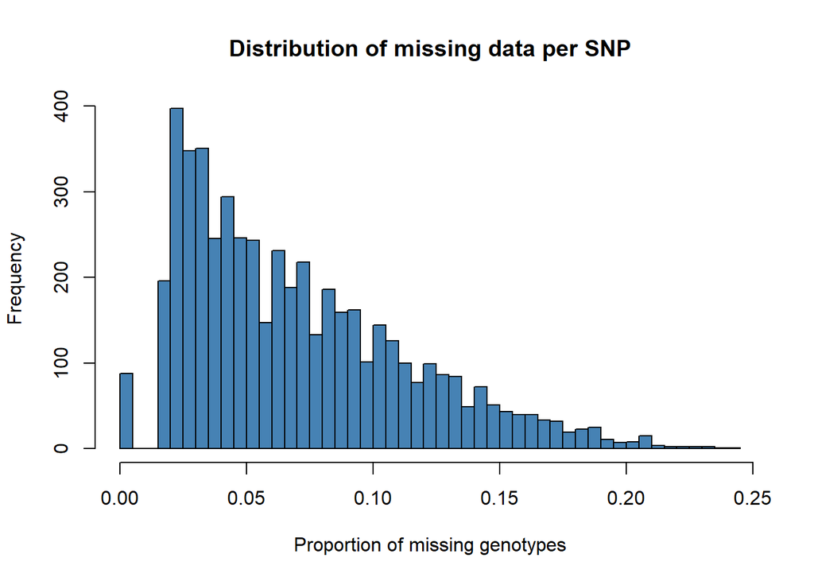

```r
#Lacanau
data_Lacanau_tot_filter_maF5[data_Lacanau_tot_filter_maF5 == "---"] <- NA
missing_prop_Lacanau <- colMeans(is.na(data_Lacanau_tot_filter_maF5) | data_Lacanau_tot_filter_maF5 == "")

hist(missing_prop_Lacanau,
     breaks = 50,
     col = "steelblue",
     main = "Distribution of missing data per SNP",
     xlab = "Proportion of missing genotypes")
```

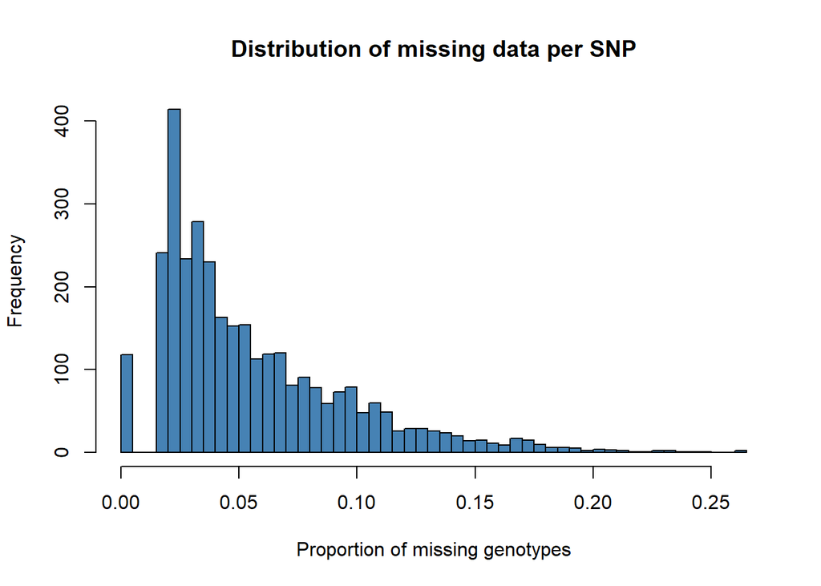

```r
missing_prop_Lacanau_5 <- data.frame(colMeans(is.na(data_Lacanau_tot_filter_maF5) | data_Lacanau_tot_filter_maF5 == ""))

#Tocchi
data_Tocchi_tot_filter_maf5[data_Tocchi_tot_filter_maf5 == "---"] <- NA
missing_prop_Tocchi <- colMeans(is.na(data_Tocchi_tot_filter_maf5) | data_Tocchi_tot_filter_maf5 == "")

hist(missing_prop_Tocchi,
     breaks = 50,
     col = "steelblue",
     main = "Distribution of missing data per SNP",
     xlab = "Proportion of missing genotypes")
```

```r
missing_prop_Tocchi_5 <- data.frame(colMeans(is.na(data_Tocchi_tot_filter_maf5) | data_Tocchi_tot_filter_maf5 == ""))
```

No need to remove any SNPs as the percentage of missing data is low.

## 5.2 Missing data per individual

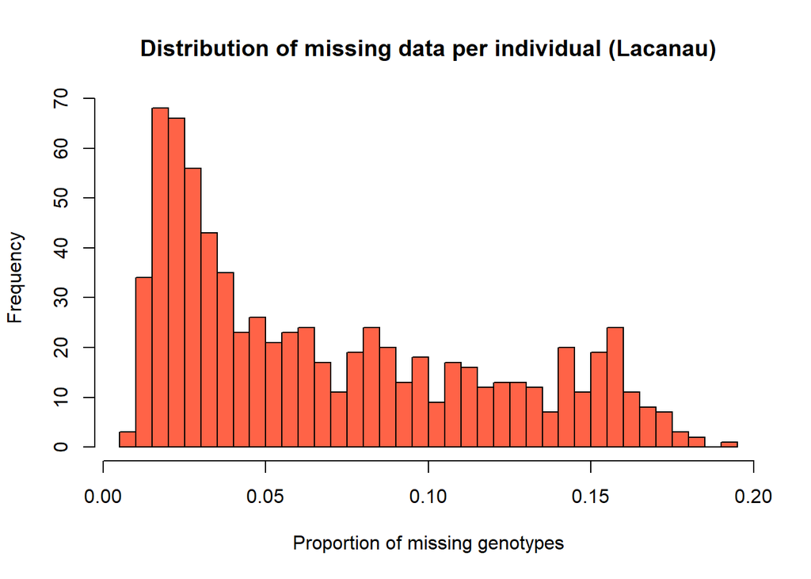

```r
# Lacanau
data_Lacanau_tot_filter_maF5[data_Lacanau_tot_filter_maF5 == "---"] <- NA

#Missing data proportion per individual (rows)
missing_prop_Lacanau_ind <- rowMeans(is.na(data_Lacanau_tot_filter_maF5) | data_Lacanau_tot_filter_maF5 == "")

#Plot distribution
hist(missing_prop_Lacanau_ind,
     breaks = 50,
     col = "tomato",
     main = "Distribution of missing data per individual (Lacanau)",
     xlab = "Proportion of missing genotypes")
```

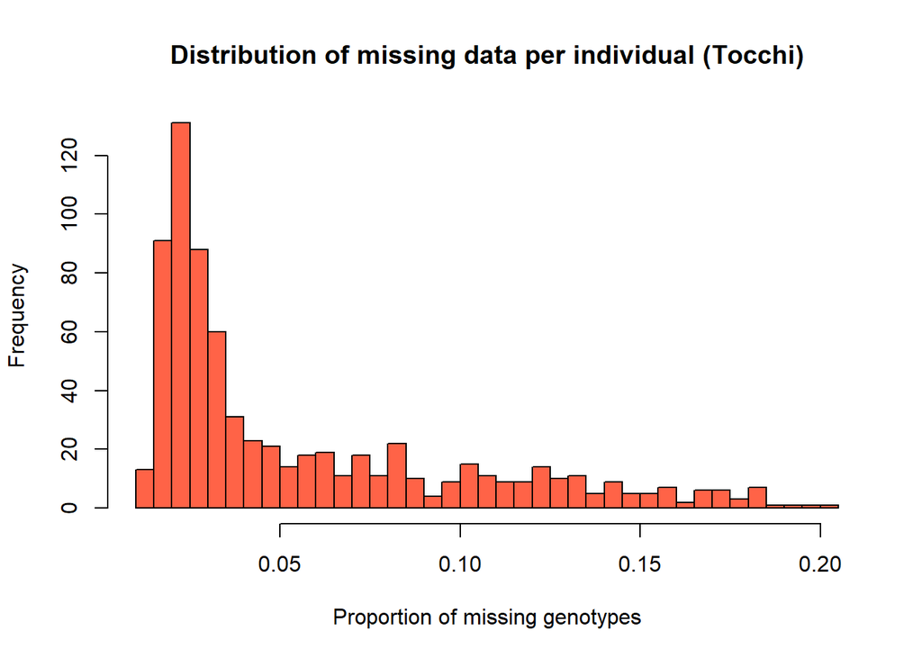

```r
missing_prop_Lacanau_ind_5 <- data.frame(ID = rownames(data_Lacanau_tot_filter_maF5),
                                       Missing_prop = missing_prop_Lacanau_ind)


#Tocchi
data_Tocchi_tot_filter_maf5[data_Tocchi_tot_filter_maf5 == "---"] <- NA

missing_prop_Tocchi_ind <- rowMeans(is.na(data_Tocchi_tot_filter_maf5) | data_Tocchi_tot_filter_maf5 == "")

hist(missing_prop_Tocchi_ind,
     breaks = 50,
     col = "tomato",
     main = "Distribution of missing data per individual (Tocchi)",
     xlab = "Proportion of missing genotypes")
```

```r
missing_prop_Tocchi_ind_5 <- data.frame(ID = rownames(data_Tocchi_tot_filter_maf5),
                                      Missing_prop = missing_prop_Tocchi_ind)
```

We have a lot of differnece in the number of SNP between the two plots but let’s see what we get

## 5.3 Computation of *Hi*

```r
#Function

compute_Hi <- function(x) {
  #Remove missing data
  x <- x[!is.na(x)]

  #Count heterozygous genotypes (two different alleles)
  hetero_count <- sum(nchar(x) == 2 & substring(x, 1, 1) != substring(x, 2, 2))

  #Count total non-missing loci
  total_non_missing <- length(x)

  #Avoid dividing by zero
  if (total_non_missing == 0) return(NA)

  return(hetero_count / total_non_missing)
}

#Compute Hi

##Lacanau
Hi_per_individual_Lacanau_maf5 <- apply(data_Lacanau_tot_filter_maF5, 1, compute_Hi)
Hi_maf5_df_Lacanau <- data.frame(
  ID = data_Lacanau_tot_filter_maF5$POP,
  Hi = Hi_per_individual_Lacanau_maf5
)

save(Hi_maf5_df_Lacanau,file="Results/Chapter3/Pinaster/Genetic_diversity/Comparison_adults_juveniles/Hi/Values/Hi_maf5_df_Lacanau.Rdata")

##Tocchi
Hi_per_individual_Tocchi_maf5 <- apply(data_Tocchi_tot_filter_maf5, 1, compute_Hi)
Hi_maf5_df_Tocchi <- data.frame(
  ID = data_Tocchi_tot_filter_maf5$POP,
  Hi = Hi_per_individual_Tocchi_maf5
)

save(Hi_maf5_df_Tocchi,file="Results/Chapter3/Pinaster/Genetic_diversity/Comparison_adults_juveniles/Hi/Values/Hi_maf5_df_Tocchi.Rdata")
```

## 5.4 Plot

```r
#Define the juveniles and adults

Hi_maf5_df_Lacanau <- Hi_maf5_df_Lacanau %>%
  dplyr::mutate(age = ifelse(grepl("FR_PP", ID), "Offspring", "Adult"))

Hi_maf5_df_Tocchi <- Hi_maf5_df_Tocchi %>%
  dplyr::mutate(age = ifelse(grepl("IT_PP", ID), "Offspring", "Adult"))
```

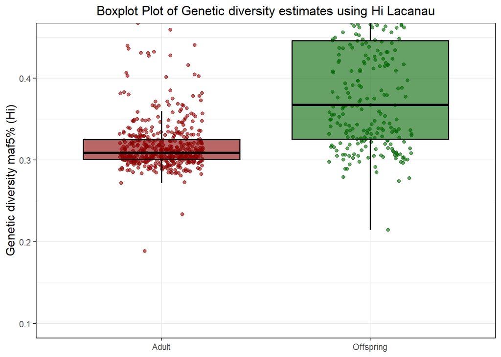

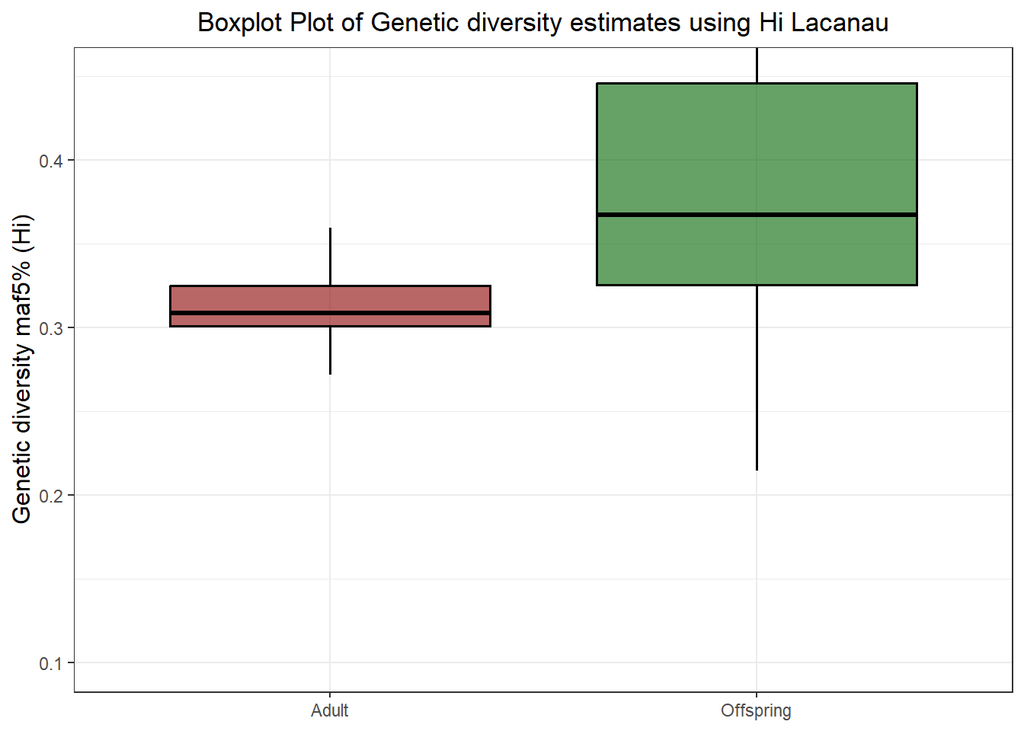

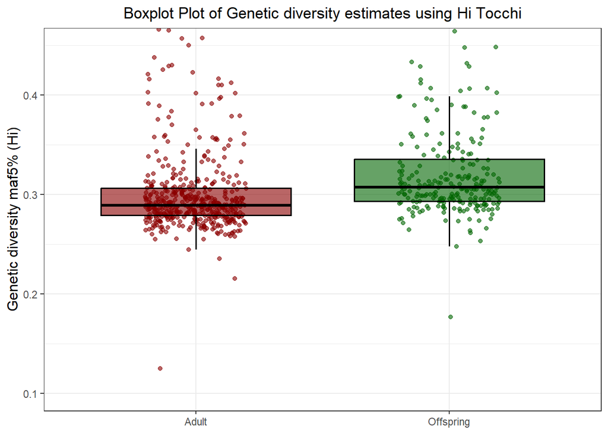

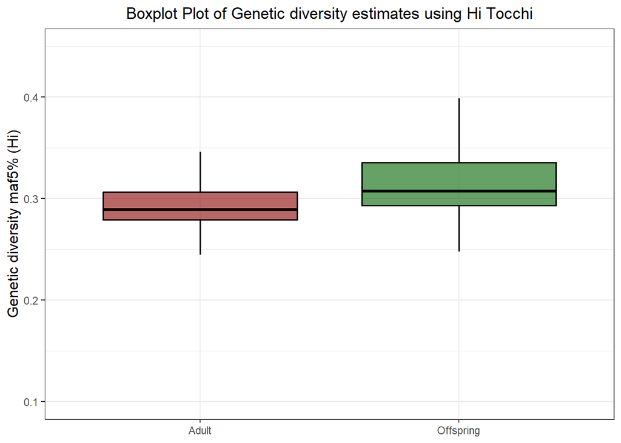

```r
list_plots <- c("Lacanau","Tocchi")

for(x in 1:length(list_plots)){

  plot <- list_plots[x]
  df_Hi<- get(paste0("Hi_maf5_df_",plot))

  t_test_result <- t.test(Hi ~ age, data = df_Hi)

    assign(paste0("Hi_maf5_difference_across_adults_juv_",plot),t_test_result)

  #Plot
Hi_boxplot <- ggplot(df_Hi, aes(x = age, y = Hi, fill = age)) +
  geom_jitter(aes(color = age), width = 0.2, alpha = 0.6, size = 1.5, show.legend = FALSE) +
  geom_boxplot(outlier.shape = NA, alpha = 0.6, color = "black", size = 0.6) +
  scale_fill_manual(values = c("darkred", "darkgreen")) +
  scale_color_manual(values = c("darkred", "darkgreen")) +
  labs(
    title = paste0("Boxplot Plot of Genetic diversity estimates using Hi ", plot),
    #x = "Group-age",
    y = "Genetic diversity maf5% (Hi)"
  ) +
  coord_cartesian(ylim = c(0.1, 0.45)) +
  scale_y_continuous(breaks = seq(0.1, 0.45, by = 0.1)) +
  theme_bw() +
  theme(
    plot.title = element_text(hjust = 0.5),
    legend.position = "none",
    #axis.text.x = element_text(angle = 0, hjust = 0.5),
    #axis.title.x = element_text(size = 12),
    axis.title.x = element_blank(),
    axis.title.y = element_text(size = 12)
  )

plot(Hi_boxplot)

pdf(paste0("Results/Chapter3/Pinaster/Genetic_diversity/Comparison_adults_juveniles/Hi/figures/Hi_maf5_boxplot_",plot,".pdf"), width = 8, height = 6)
print(Hi_boxplot)
dev.off()

Hi_boxplot_wo_points <- ggplot(df_Hi, aes(x = age, y = Hi, fill = age)) +
  #geom_jitter(aes(color = Group), width = 0.2, alpha = 0.6, size = 1.5, show.legend = FALSE) + #points
  geom_boxplot(outlier.shape = NA, alpha = 0.6, color = "black", size = 0.6) +
  scale_fill_manual(values = c("darkred", "darkgreen")) +
  scale_color_manual(values = c("darkred", "darkgreen")) +
  labs(
    title = paste0("Boxplot Plot of Genetic diversity estimates using Hi ", plot),
    #x = "Group-age",
    y = "Genetic diversity maf5% (Hi)"
  ) +
  coord_cartesian(ylim = c(0.1, 0.45)) +
  scale_y_continuous(breaks = seq(0.1, 0.45, by = 0.1)) +
  theme_bw() +
  theme(
    plot.title = element_text(hjust = 0.5),
    legend.position = "none",
    axis.title.x = element_blank(),
    axis.title.y = element_text(size = 12)
  )

plot(Hi_boxplot_wo_points)

pdf(paste0("Results/Chapter3/Pinaster/Genetic_diversity/Comparison_adults_juveniles/Hi/figures/Hi_maf5_boxplot_wopoints_",plot,".pdf"), width = 8, height = 6)
print(Hi_boxplot_wo_points)
dev.off()

}
```

```r
print(Hi_maf5_difference_across_adults_juv_Lacanau)
```

```
##
##  Welch Two Sample t-test
##
## data:  Hi by age
## t = -14.532, df = 296.63, p-value < 2.2e-16
## alternative hypothesis: true difference in means between group Adult and group Offspring is not equal to 0
## 95 percent confidence interval:
##  -0.07760527 -0.05909333
## sample estimates:
##     mean in group Adult mean in group Offspring
##               0.3175241               0.3858734
```

```r
print(Hi_maf5_difference_across_adults_juv_Tocchi)
```

```
##
##  Welch Two Sample t-test
##
## data:  Hi by age
## t = -5.2973, df = 442.37, p-value = 1.857e-07
## alternative hypothesis: true difference in means between group Adult and group Offspring is not equal to 0
## 95 percent confidence interval:
##  -0.02958309 -0.01357206
## sample estimates:
##     mean in group Adult mean in group Offspring
##               0.3030800               0.3246576
```

Combined plot:

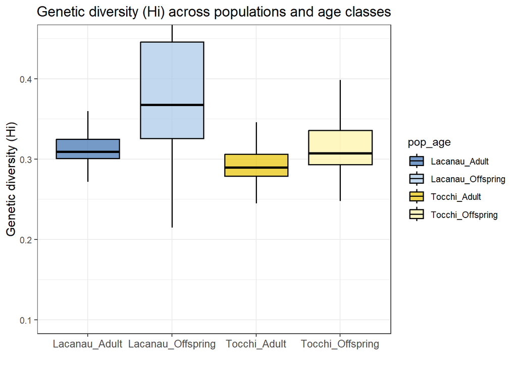

```r
#Merge the two datasets and create a new combined category
df_all <- rbind(
  transform(Hi_maf5_df_Lacanau, population = "Lacanau"),
  transform(Hi_maf5_df_Tocchi, population = "Tocchi")
)

#Create combined factor for x-axis: Population + Age
df_all$pop_age <- factor(
  paste(df_all$population, df_all$age, sep = "_"),
  levels = c("Lacanau_Adult","Lacanau_Offspring",
             "Tocchi_Adult","Tocchi_Offspring")
)

custom_colors <- c(
  "Lacanau_Adult"     = "#3A6FB0",
   "Lacanau_Offspring" = "#A7C7E7",
  "Tocchi_Adult"      = "#E6C300",
    "Tocchi_Offspring"  = "#FFF4A3"
)

legend_colors <- c(
  "Lacanau" = "#3A6FB0",
  "Tocchi"  = "#E6C300"
)

combined_boxplot <- ggplot(df_all, aes(x = pop_age, y = Hi, fill = pop_age)) +
  geom_boxplot(outlier.shape = NA, alpha = 0.7, color = "black", size = 0.6) +
  #geom_jitter(width = 0.15, alpha = 0.5, size = 1.4, show.legend = FALSE) +
  #scale_fill_manual(values = legend_colors, name = "Population") +#custom_colors
  labs(
    title = "Genetic diversity (Hi) across populations and age classes",
    x = "",
    y = "Genetic diversity (Hi)"
  ) +
   scale_fill_manual(values = custom_colors) +
  coord_cartesian(ylim = c(0.1, 0.45)) +
  theme_bw() +
  theme(
    plot.title = element_text(hjust = 0.5, size = 14),
    axis.title = element_text(size = 12),
    axis.text.x = element_text(size = 10)
  )

plot(combined_boxplot)
```

Difference significance:

```r
#One way anova to see if groups are differents
anova_result <- aov(Hi ~ pop_age, data = df_all)
summary(anova_result)
```

```
##               Df Sum Sq Mean Sq F value Pr(>F)
## pop_age        3  1.183  0.3943   164.1 <2e-16 ***
## Residuals   1477  3.549  0.0024
## ---
## Signif. codes:  0 '***' 0.001 '**' 0.01 '*' 0.05 '.' 0.1 ' ' 1
```

```r
tukey_result <- TukeyHSD(anova_result)
tukey_result
```

```
##   Tukey multiple comparisons of means
##     95% family-wise confidence level
##
## Fit: aov(formula = Hi ~ pop_age, data = df_all)
##
## $pop_age
##                                            diff          lwr          upr
## Lacanau_Offspring-Lacanau_Adult     0.068349301  0.058571234  0.078127369
## Tocchi_Adult-Lacanau_Adult         -0.014444112 -0.022482827 -0.006405397
## Tocchi_Offspring-Lacanau_Adult      0.007133464 -0.002657755  0.016924682
## Tocchi_Adult-Lacanau_Offspring     -0.082793413 -0.092625064 -0.072961763
## Tocchi_Offspring-Lacanau_Offspring -0.061215838 -0.072525496 -0.049906180
## Tocchi_Offspring-Tocchi_Adult       0.021577576  0.011732846  0.031422306
##                                        p adj
## Lacanau_Offspring-Lacanau_Adult    0.0000000
## Tocchi_Adult-Lacanau_Adult         0.0000246
## Tocchi_Offspring-Lacanau_Adult     0.2397838
## Tocchi_Adult-Lacanau_Offspring     0.0000000
## Tocchi_Offspring-Lacanau_Offspring 0.0000000
## Tocchi_Offspring-Tocchi_Adult      0.0000001
```

```r
anova_result_pop <- aov(Hi ~ population, data = df_all)
summary(anova_result_pop)
```

```
##               Df Sum Sq Mean Sq F value Pr(>F)
## population     1  0.330   0.330   110.9 <2e-16 ***
## Residuals   1479  4.401   0.003
## ---
## Signif. codes:  0 '***' 0.001 '**' 0.01 '*' 0.05 '.' 0.1 ' ' 1
```

# 6 Comparison of SNP sets and number of SNPs

Let’s compare the same SNPs or the same number of SNPs

```r
shared_snps <- intersect(colnames(data_Lacanau_tot_filter_maF5),
                         colnames(data_Tocchi_tot_filter_maf5))

#Reduce datasets to only these SNPs
data_Lacanau_tot_filter_maf5_reduce <- data_Lacanau_tot_filter_maF5[, shared_snps]

data_Tocchi_tot_filter_maf5_reduce <- data_Tocchi_tot_filter_maf5[, shared_snps]
```

## 6.1 Computation of *Hi*

```r
#Function

compute_Hi <- function(x) {
  #Remove missing data
  x <- x[!is.na(x)]

  #Count heterozygous genotypes (two different alleles)
  hetero_count <- sum(nchar(x) == 2 & substring(x, 1, 1) != substring(x, 2, 2))

  #Count total non-missing loci
  total_non_missing <- length(x)

  #Avoid dividing by zero
  if (total_non_missing == 0) return(NA)

  return(hetero_count / total_non_missing)
}

#Compute Hi

## Lacanau
Hi_sameSNPs_per_individual_Lacanau <- apply(data_Lacanau_tot_filter_maf5_reduce, 1, compute_Hi)
Hi_sameSNPs_df_Lacanau <- data.frame(
  ID = data_Lacanau_tot_filter_maf5_reduce$POP,
  Hi = Hi_sameSNPs_per_individual_Lacanau
)

save(Hi_sameSNPs_df_Lacanau,file="Results/Chapter3/Pinaster/Genetic_diversity/Comparison_adults_juveniles/Hi/Values/Hi_sameSNPs_df_Lacanau.Rdata")

## Tocchi
Hi_sameSNPs_per_individual_Tocchi <- apply(data_Tocchi_tot_filter_maf5_reduce, 1, compute_Hi)
Hi_same_SNPs_df_Tocchi <- data.frame(
  ID = data_Tocchi_tot_filter_maf5_reduce$POP,
  Hi = Hi_sameSNPs_per_individual_Tocchi
)

save(Hi_same_SNPs_df_Tocchi,file="Results/Chapter3/Pinaster/Genetic_diversity/Comparison_adults_juveniles/Hi/Values/Hi_same_SNPs_df_Tocchi.Rdata")
```

## 6.2 Plot

We can compare Adults and offsprings values

```r
Hi_sameSNPs_df_Lacanau <- Hi_sameSNPs_df_Lacanau %>%
  dplyr::mutate(age = ifelse(grepl("FR_PP", ID), "Offspring", "Adult"))

Hi_sameSNPs_df_Tocchi <- Hi_same_SNPs_df_Tocchi %>%
  dplyr::mutate(age = ifelse(grepl("IT_PP", ID), "Offspring", "Adult"))
```

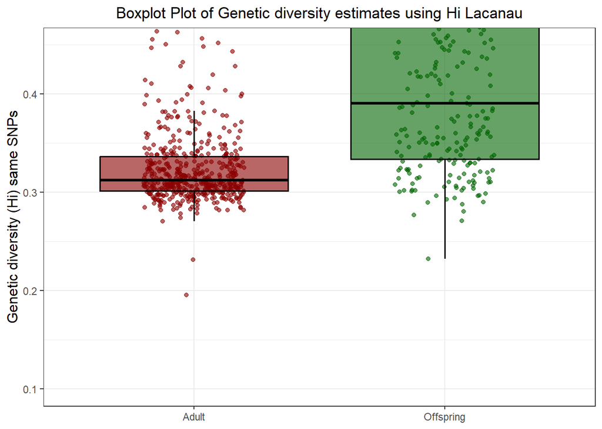

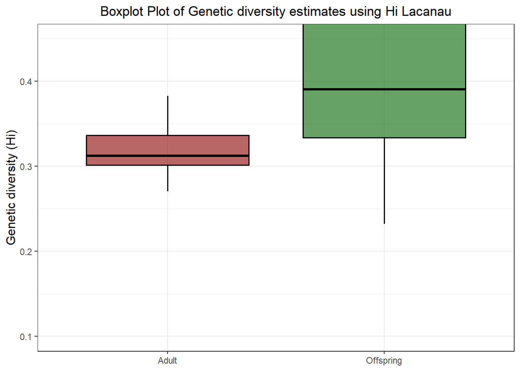

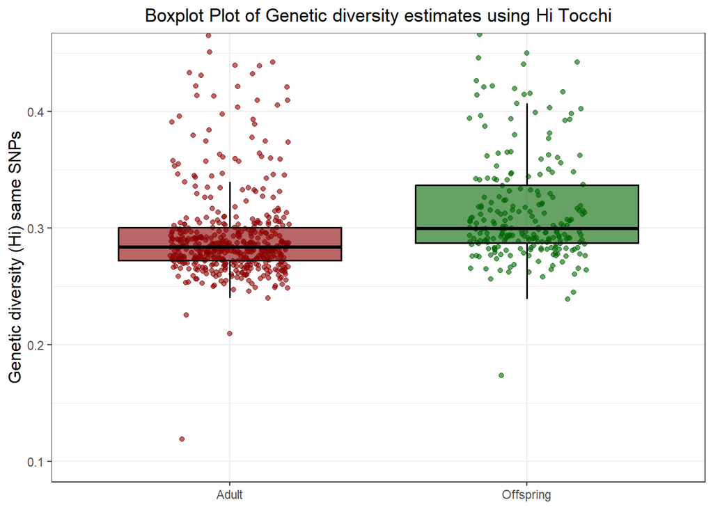

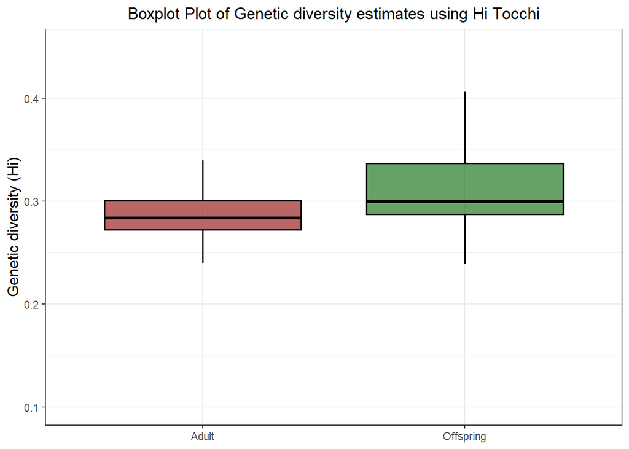

```r
list_plots <- c("Lacanau","Tocchi")

for(x in 1:length(list_plots)){

  plot <- list_plots[x]
  df_Hi<- get(paste0("Hi_sameSNPs_df_",plot))

  t_test_result <- t.test(Hi ~ age, data = df_Hi)

    assign(paste0("Hi_sameSNPs_difference_across_adults_juv_",plot),t_test_result)


  #Plot
Hi_boxplot <- ggplot(df_Hi, aes(x = age, y = Hi, fill = age)) +
  geom_jitter(aes(color = age), width = 0.2, alpha = 0.6, size = 1.5, show.legend = FALSE) +
  geom_boxplot(outlier.shape = NA, alpha = 0.6, color = "black", size = 0.6) +
  scale_fill_manual(values = c("darkred", "darkgreen")) +
  scale_color_manual(values = c("darkred", "darkgreen")) +
  labs(
    title = paste0("Boxplot Plot of Genetic diversity estimates using Hi ", plot),
    #x = "Group-age",
    y = "Genetic diversity (Hi) same SNPs"
  ) +
  coord_cartesian(ylim = c(0.1, 0.45)) +
  scale_y_continuous(breaks = seq(0.1, 0.45, by = 0.1)) +
  theme_bw() +
  theme(
    plot.title = element_text(hjust = 0.5),
    legend.position = "none",
    #axis.text.x = element_text(angle = 0, hjust = 0.5),
    #axis.title.x = element_text(size = 12),
    axis.title.x = element_blank(),
    axis.title.y = element_text(size = 12)
  )

plot(Hi_boxplot)

pdf(paste0("Results/Chapter3/Pinaster/Genetic_diversity/Comparison_adults_juveniles/Hi/figures/Hi_sameSNPs_boxplot_",plot,".pdf"), width = 8, height = 6)
print(Hi_boxplot)
dev.off()

Hi_boxplot_wo_points <- ggplot(df_Hi, aes(x = age, y = Hi, fill = age)) +
  #geom_jitter(aes(color = Group), width = 0.2, alpha = 0.6, size = 1.5, show.legend = FALSE) + #points
  geom_boxplot(outlier.shape = NA, alpha = 0.6, color = "black", size = 0.6) +
  scale_fill_manual(values = c("darkred", "darkgreen")) +
  scale_color_manual(values = c("darkred", "darkgreen")) +
  labs(
    title = paste0("Boxplot Plot of Genetic diversity estimates using Hi ", plot),
    #x = "Group-age",
    y = "Genetic diversity (Hi)"
  ) +
  coord_cartesian(ylim = c(0.1, 0.45)) +
  scale_y_continuous(breaks = seq(0.1, 0.45, by = 0.1)) +
  theme_bw() +
  theme(
    plot.title = element_text(hjust = 0.5),
    legend.position = "none",
    axis.title.x = element_blank(),
    axis.title.y = element_text(size = 12)
  )

plot(Hi_boxplot_wo_points)

pdf(paste0("Results/Chapter3/Pinaster/Genetic_diversity/Comparison_adults_juveniles/Hi/figures/Hi_sameSNPs_boxplot_wopoints_",plot,".pdf"), width = 8, height = 6)
print(Hi_boxplot_wo_points)
dev.off()

}
```

```r
print(Hi_sameSNPs_difference_across_adults_juv_Lacanau)
```

```
##
##  Welch Two Sample t-test
##
## data:  Hi by age
## t = -15.074, df = 307.21, p-value < 2.2e-16
## alternative hypothesis: true difference in means between group Adult and group Offspring is not equal to 0
## 95 percent confidence interval:
##  -0.09250467 -0.07114274
## sample estimates:
##     mean in group Adult mean in group Offspring
##               0.3245023               0.4063260
```

```r
print(Hi_sameSNPs_difference_across_adults_juv_Tocchi)
```

```
##
##  Welch Two Sample t-test
##
## data:  Hi by age
## t = -5.0445, df = 435.09, p-value = 6.69e-07
## alternative hypothesis: true difference in means between group Adult and group Offspring is not equal to 0
## 95 percent confidence interval:
##  -0.03260323 -0.01432075
## sample estimates:
##     mean in group Adult mean in group Offspring
##               0.2989279               0.3223899
```

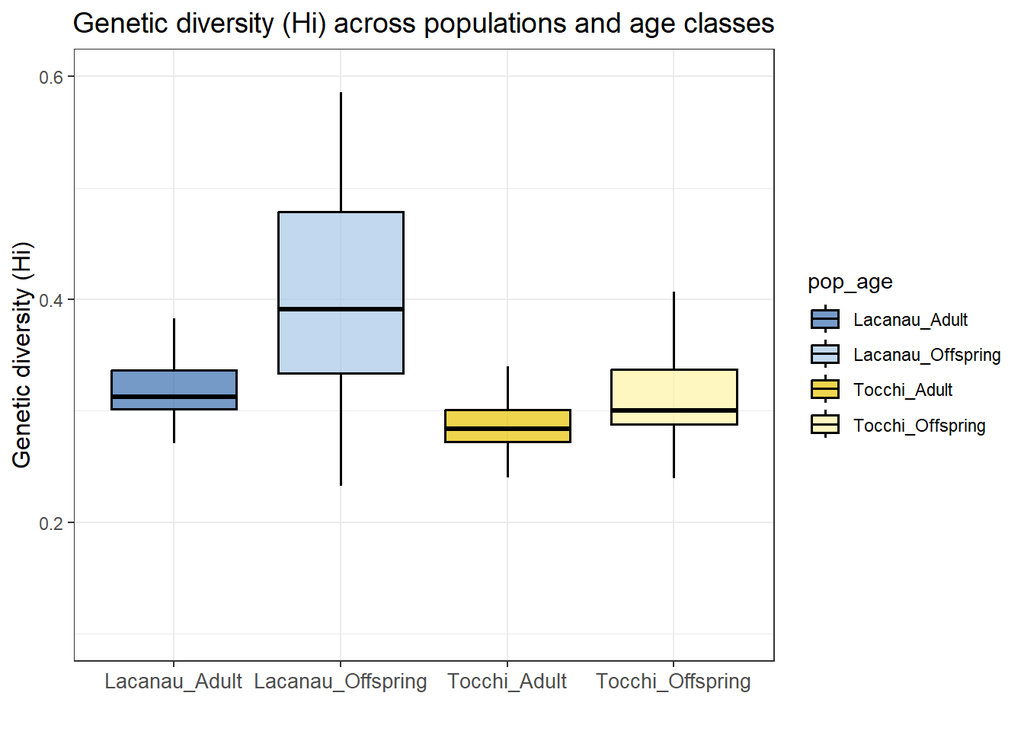

```r
#Merge the two datasets and create a new combined category
df_all <- rbind(
  transform(Hi_sameSNPs_df_Lacanau, population = "Lacanau"),
  transform(Hi_sameSNPs_df_Tocchi, population = "Tocchi")
)

#Create combined factor for x-axis: Population + Age
df_all$pop_age <- factor(
  paste(df_all$population, df_all$age, sep = "_"),
  levels = c("Lacanau_Adult","Lacanau_Offspring",
             "Tocchi_Adult","Tocchi_Offspring")
)

custom_colors <- c(
  "Lacanau_Adult"     = "#3A6FB0",
   "Lacanau_Offspring" = "#A7C7E7",
  "Tocchi_Adult"      = "#E6C300",
    "Tocchi_Offspring"  = "#FFF4A3"
)

legend_colors <- c(
  "Lacanau" = "#3A6FB0",
  "Tocchi"  = "#E6C300"
)

combined_boxplot <- ggplot(df_all, aes(x = pop_age, y = Hi, fill = pop_age)) +
  geom_boxplot(outlier.shape = NA, alpha = 0.7, color = "black", size = 0.6) +
  #geom_jitter(width = 0.15, alpha = 0.5, size = 1.4, show.legend = FALSE) +
  #scale_fill_manual(values = legend_colors, name = "Population") +#custom_colors
  labs(
    title = "Genetic diversity (Hi) across populations and age classes",
    x = "",
    y = "Genetic diversity (Hi)"
  ) +
   scale_fill_manual(values = custom_colors) +
  coord_cartesian(ylim = c(0.1, 0.6)) +
  theme_bw() +
  theme(
    plot.title = element_text(hjust = 0.5, size = 14),
    axis.title = element_text(size = 12),
    axis.text.x = element_text(size = 10)
  )

plot(combined_boxplot)
```

Test significance:

```r
#One way anova to see if groups are differents
anova_result <- aov(Hi ~ pop_age, data = df_all)
summary(anova_result)
```

```
##               Df Sum Sq Mean Sq F value Pr(>F)
## pop_age        3  1.947  0.6490   202.3 <2e-16 ***
## Residuals   1477  4.738  0.0032
## ---
## Signif. codes:  0 '***' 0.001 '**' 0.01 '*' 0.05 '.' 0.1 ' ' 1
```

```r
tukey_result <- TukeyHSD(anova_result)
tukey_result
```

```
##   Tukey multiple comparisons of means
##     95% family-wise confidence level
##
## Fit: aov(formula = Hi ~ pop_age, data = df_all)
##
## $pop_age
##                                            diff         lwr          upr
## Lacanau_Offspring-Lacanau_Adult     0.081823707  0.07052461  0.093122805
## Tocchi_Adult-Lacanau_Adult         -0.025574363 -0.03486354 -0.016285182
## Tocchi_Offspring-Lacanau_Adult     -0.002112374 -0.01342667  0.009201921
## Tocchi_Adult-Lacanau_Offspring     -0.107398070 -0.11875909 -0.096037054
## Tocchi_Offspring-Lacanau_Offspring -0.083936081 -0.09700502 -0.070867145
## Tocchi_Offspring-Tocchi_Adult       0.023461989  0.01208586  0.034838119
##                                        p adj
## Lacanau_Offspring-Lacanau_Adult    0.0000000
## Tocchi_Adult-Lacanau_Adult         0.0000000
## Tocchi_Offspring-Lacanau_Adult     0.9634849
## Tocchi_Adult-Lacanau_Offspring     0.0000000
## Tocchi_Offspring-Lacanau_Offspring 0.0000000
## Tocchi_Offspring-Tocchi_Adult      0.0000008
```

```r
anova_result_pop <- aov(Hi ~ population, data = df_all)
summary(anova_result_pop)
```

```
##               Df Sum Sq Mean Sq F value Pr(>F)
## population     1  0.744  0.7439   185.2 <2e-16 ***
## Residuals   1479  5.941  0.0040
## ---
## Signif. codes:  0 '***' 0.001 '**' 0.01 '*' 0.05 '.' 0.1 ' ' 1
```